# Analysis of the New York Philharmonic Orchestra's Concert Programming

## Spring 2024 Data Science Project

### Jeizen Jose, Wolfgang Koch-Paiz

- Member 1: Jeizen Jose, Contribution: 90% (did not contribute to B, H – GitHub stuff)
- Member 2: Wolgang Koch-Paiz, Contribution: 100% (did contribute to all checkpoints, H – GitHub stuff)

"We, all team members, agree together that the above information is true, and we are confident about our contributions to this submitted project/final tutorial."

Jeizen Jose, Wolfgang Koch-Paiz

– 5/5/24

Jeizen Jose:

I helped set up the final project, which includes creating the python notebook file that we were going to work on, making the GitHub repository and setting up GitHub pages where we would submit the project, drawing out the outline that follows the final project format criteria, and transferring our checkpoint 2 submission into the final project checkpoint 3, reorganizing it, and filling in the details in the introduction, data curation, and exploratory data analysis sections. Wolfgang and I initially divided the work for checkpoint A, B, and C, but I struggled with some issues in checkpoint C, so Wolfgang had to take charge of implementing that section. However, I was still able to help in writing the conclusion part of section C/ checkpoint 2. We also decided to each come up with something for the primary analysis, visualization, and insights and conclusions parts of the final project and then compare each other's work and combine them together and include that in the final project. I went to office hours to seek help and check with a TA about my work and they said that I was on the right track, but upon meeting up with my groupmate, we discovered that my work would not work out for the final submission so we settled for my groupmate's work on the final project. I did read through the final project to check for anything that is out of order, such as grammatical errors or spelling mistakes, and helped correct them.

Wolfgang Koch-Paiz:

The content on this page comes after an at least reasonable effort from BOTH members. Our working plan began as a divide and conquer, where for contribution checkpoints A, B, and C, the idea was to split the work, each do part of what was needed to submit, and do a presubmission review of each other's work. Jeizen encountered some difficulty implementing her portion of checkpoint C, and so I ended up taking that over, in addition to doing the rest of checkpoints A, B, and C. However, she did put in a good effort and sought help during office hours. We then decided to change strategies (with the hopes of forcing a more even workload), planning to do checkpoints D, E, and F independently and combine our work later by selecting the better portions from each person's material. Ultimately, we decided to use my material because of technical issues Jeizen encountered, such that her work was not of a standard we were comfortable including by the time we reached internal deadlines (set to accommodate busy schedules outside of class). Still, she put in a good effort and sought help during office hours. All of this is with regards to the code.

The prose for the final tutorial/ checkpoint 3 submission was written by me too, because the situation described above left me with the most intimate knowledge of the code and the steps we took. This includes the introduction and conclusion (this was not ideal, but given the situation, we thought it best).

Ultimately, the vast majority of content on this page is my material.

Jeizen was kept in the loop at every step and gave approval for submissions, etc. She read through the entire project and caught many of my spelling mistakes.

# Introduction

The aim of this data science project is two fold:

Initially we want to identify trends that have emerged in the New York Philharmoics’s concert programming over the period spanning from the 2011-12 season up until now. To do this, we will use three guiding questions:

1. Have certain composers tended to gain popularity alongside others over time?
2. Is there a relationship between composer and whether their work is featured in full or in part?
3. Is there a significant difference in the average number of performances given by the top soloists?

Answering these questions, along with trends we uncover in the process, can be used to glean insights about the public’s classical music tastes over time, since historically and presently one of the nation’s leading orchestras, the NY Phil is a good indicator of public sentiment in this regard.

Can we use our answers to help select and develop a machine learning model that estimates components of new program data? More specifically, for example, given new data with information about: composer, conductor, intermission, work title, etc., can we predict if the work is performed in whole or in part?

Concert programmers could incorperate similar models into their creative process, using them to check for the general markers of a good program as they develop new material.

Amidst all this, we will walk through and tutorialize the data science pipeline from beginning to end.

- The tutorial assumes knowledge of the pandas data analysis Python tool, as well as Python. [Read more](https://pandas.pydata.org/)

# Data Curation

The data science pipeline begins with the bulk of our data curation.

We first provide some more clarification regarding the various attributes/ features of our data, and note the many imports the rest of our project will depend on.

Our only source of data for this project is the [New York Philharmonic Performance History database](https://github.com/nyphilarchive/PerformanceHistory/), which is a collection of JSON files available on GitHub documenting the orchestra's performance history since the end of 1842. With over 20,000 records, we have opted to focus on the 2011-2012 season to present. This date range is provided as its own JSON.

Shown here for your convenience, the GitHub page contains a graphic detailing the contents of each entry in the database:

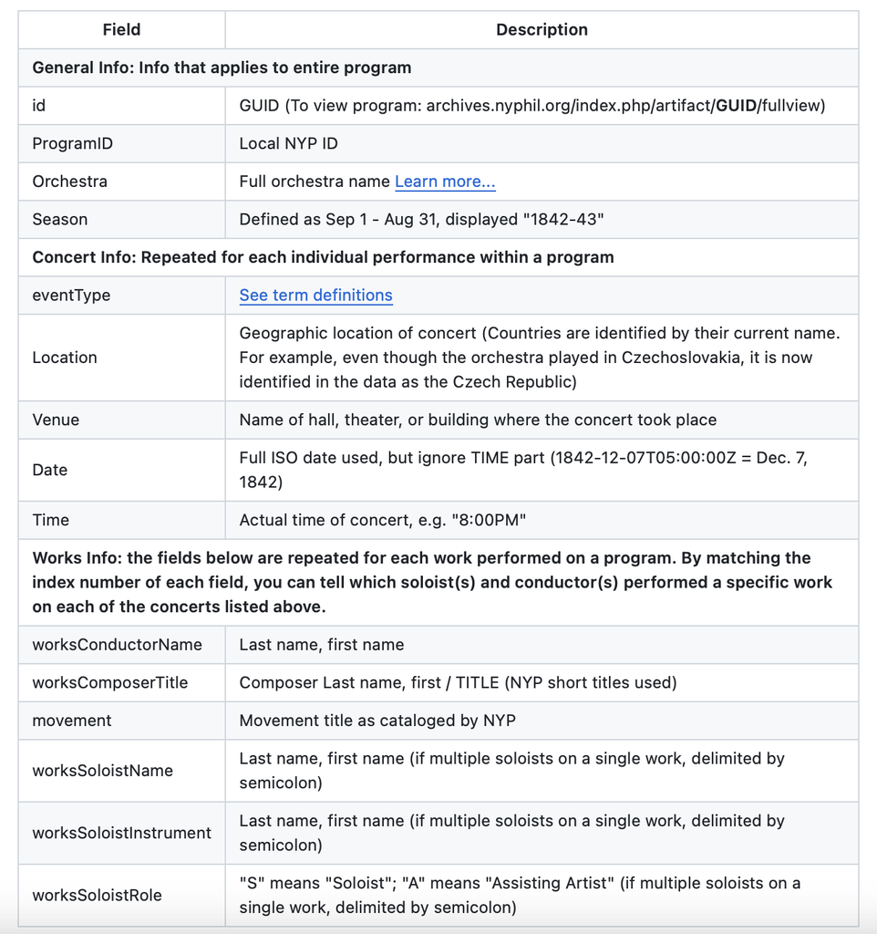

```python
from IPython.display import Image
Image("Field_Descriptions.png", width = 550, height = 600)
```

We will need the following imports/ libraries/ modules:

```python
import pandas as pd
import matplotlib.pyplot as plt
import seaborn as sb
import ast
import json
from scipy.stats import chi2_contingency
from scipy.stats import f_oneway
from sklearn.tree import plot_tree
from sklearn.metrics import accuracy_score, classification_report
from sklearn.model_selection import train_test_split
from sklearn.tree import DecisionTreeClassifier
```

Now we begin processing the data. To do this, we load the JSON file into a [pandas](https://pandas.pydata.org/docs/index.html) [DataFrame](https://pandas.pydata.org/docs/reference/api/pandas.DataFrame.html) for easy manipulation/ cleaning.

```python
with open("2011-12_TO_NOW.json", "r") as file:
  data = json.load(file)

programs_list = data["programs"]

raw_programs_df = pd.DataFrame(programs_list)

raw_programs_df # Our first raw DataFrame.
```

|  | id | programID | orchestra | season | concerts | works |
| --- | --- | --- | --- | --- | --- | --- |
| 0 | 7358870b-65c8-43d5-ab56-514bde52db88-0.1 | 11640 | New York Philharmonic | 2011-12 | [{'eventType': 'Non-Subscription', 'Location':... | [{'ID': '5733*', 'composerName': 'Bernstein, ... |
| 1 | e0d79f25-6340-4369-a528-962bb03eabd7-0.1 | 11878 | NYP Presentation | 2011-12 | [{'eventType': 'Insight Series', 'Location': '... | [{'ID': '5725*5', 'composerName': 'Corigliano,... |
| 2 | f2a4cfed-5e56-4980-8d6f-8765acf18c82-0.1 | 10691 | New York Philharmonic | 2011-12 | [{'eventType': 'Special', 'Location': 'Manhatt... | [{'ID': '3965*', 'composerName': 'Anthem,', 'w... |
| 3 | 67531fff-a9e0-46ef-a494-033d51d2856f-0.1 | 10692 | New York Philharmonic | 2011-12 | [{'eventType': 'Parks', 'Location': 'Manhattan... | [{'ID': '50376*1', 'composerName': 'Verdi, Gi... |
| 4 | 57b28df9-2fdc-4a14-98fb-f345fd31b3e0-0.1 | 11753 | New York Philharmonic | 2011-12 | [{'eventType': 'Special', 'Location': 'Manhatt... | [{'ID': '9003*7', 'composerName': 'Wagner, Ri... |
| ... | ... | ... | ... | ... | ... | ... |
| 1516 | 6ef39faa-4f6e-442f-8da5-0b690ebd3a3c-0.1 | 14922 | New York Philharmonic | 2023-24 | [{'eventType': 'Subscription Season', 'Locatio... | [{'ID': '50025*', 'composerName': 'Tchaikovsky... |
| 1517 | 7d1852f7-6da8-4499-b916-a1c15d187985-0.1 | 14924 | Musicians from the New York Philharmonic | 2023-24 | [{'eventType': 'Chamber', 'Location': 'Manhatt... | [{'ID': '12981*', 'composerName': 'Vanhal, Jo... |
| 1518 | bcee37da-f02c-4a88-8811-8aaca176e3a6-0.1 | 14804 | New York Philharmonic | 2023-24 | [{'eventType': 'Subscription Season', 'Locatio... | [{'ID': '53976*', 'composerName': 'Handel, Ge... |
| 1519 | 243e291b-0574-46c8-a123-8f291aa5f86d-0.1 | 14925 | Musicians from the New York Philharmonic | 2023-24 | [{'eventType': 'Holiday Brass', 'Location': 'M... | [{'ID': '9453*', 'composerName': 'Pierpont, J... |
| 1520 | f84d8d54-92cc-42f8-84be-35ff5336322b-0.1 | 14805 | New York Philharmonic | 2023-24 | [{'eventType': 'Non-Subscription', 'Location':... | [{'ID': '13656*', 'composerName': 'Goransson [... |

1521 rows × 6 columns

The JSON structure is super nested, making the resulting 'raw_programs_df' difficult to work with. So, we break it up into separate DataFrame objects, one for concerts, another for works, and another for soloists. The 'programID' field will be used to relate each of them.

First we create 'raw_concerts_df.' By iterating through each row/ program of 'raw_programs_df,' we isolate each program's 'concerts' column, and iterate through that to isolate each associated concert. With access to individual concert's data, we include the corresponding 'programID' and append each concert to a list, 'concert_list.' Finally we turn that list into 'raw_concerts_df,' which comes out MUCH better!

```python
concerts_list = []

for i, row in raw_programs_df.iterrows():

  id = row["programID"]

  for concert in row["concerts"]: # Each concert cell in a 'raw_programs_df' row can contain several concerts.
    concert["programID"] = id
    concerts_list.append(concert)

raw_concerts_df = pd.DataFrame(concerts_list)

raw_concerts_df
```

|  | eventType | Location | Venue | Date | Time | programID |
| --- | --- | --- | --- | --- | --- | --- |
| 0 | Non-Subscription | Manhattan, NY | Avery Fisher Hall | 2011-09-07T04:00:00Z | 7:30PM | 11640 |
| 1 | Non-Subscription | Manhattan, NY | Avery Fisher Hall | 2011-09-08T04:00:00Z | 7:30PM | 11640 |
| 2 | Insight Series | Manhattan, NY | The Stanley H. Kaplan Penthouse | 2011-09-09T04:00:00Z | 6:30PM | 11878 |
| 3 | Special | Manhattan, NY | Avery Fisher Hall | 2011-09-10T04:00:00Z | 7:30PM | 10691 |
| 4 | Parks | Manhattan, NY | The Great Lawn, Central Park | 2011-09-15T04:00:00Z | 8:00PM | 10692 |
| ... | ... | ... | ... | ... | ... | ... |
| 2416 | Holiday Brass | Manhattan, NY | David Geffen Hall | 2023-12-17T05:00:00Z | 2:00PM | 14925 |
| 2417 | Non-Subscription | Manhattan, NY | David Geffen Hall | 2023-12-20T05:00:00Z | 7:30PM | 14805 |
| 2418 | Non-Subscription | Manhattan, NY | David Geffen Hall | 2023-12-21T05:00:00Z | 7:30PM | 14805 |
| 2419 | Non-Subscription | Manhattan, NY | David Geffen Hall | 2023-12-22T05:00:00Z | 8:00PM | 14805 |
| 2420 | Non-Subscription | Manhattan, NY | David Geffen Hall | 2023-12-23T05:00:00Z | 8:00PM | 14805 |

2421 rows × 6 columns

We take a similar approach to create 'raw_works_df.'

```python
works_list = []

for i, row in raw_programs_df.iterrows():

  id = row["programID"]

  for work in row["works"]: # Each works cell in a 'raw_programs_df' row can contain several works.
    work["programID"] = id
    works_list.append(work)

raw_works_df = pd.DataFrame(works_list)

raw_works_df
```

|  | ID | composerName | workTitle | conductorName | soloists | programID | interval | movement |
| --- | --- | --- | --- | --- | --- | --- | --- | --- |
| 0 | 5733* | Bernstein, Leonard | WEST SIDE STORY (WITH FILM) | Newman, David | [] | 11640 | NaN | NaN |
| 1 | 0* | NaN | NaN | NaN | [] | 11640 | Intermission | NaN |
| 2 | 5725*5 | Corigliano, John, Jr. | ONE SWEET MORNING | NaN | [{'soloistName': 'Duke, Cherry', 'soloistInstr... | 11878 | NaN | One Sweet Morning |
| 3 | 52611* | Barber, Samuel | ADAGIO FOR STRINGS | NaN | [{'soloistName': 'Kim, Michelle', 'soloistInst... | 11878 | NaN | NaN |
| 4 | 11812* | Discussion, | DISCUSSION | NaN | [{'soloistName': 'Wiprud, Theodore', 'soloistI... | 11878 | NaN | NaN |
| ... | ... | ... | ... | ... | ... | ... | ... | ... |
| 7907 | 13788* | Carpenter, Richard | MERRY CHRISTMAS, DARLING (ARR. Richard) | Smith, Philip | [{'soloistName': 'Smith, Philip', 'soloistInst... | 14925 | NaN | NaN |
| 7908 | 11763* | Gruber, Franz Xaver | SILENT NIGHT (ARR. Gates) | Smith, Philip | [] | 14925 | NaN | NaN |
| 7909 | 13789* | Wainwright, Andrew | SPANISH DANCE | Smith, Philip | [] | 14925 | NaN | NaN |
| 7910 | 13790* | Handel, George Frideric | MESSIAH: HALLELUJAH (BRASS) (ARR. Richard) | Smith, Philip | [] | 14925 | NaN | NaN |
| 7911 | 13656* | Goransson [Göransson], Ludwig | BLACK PANTHER LIVE TO FILM | Parnther, Anthony | [{'soloistName': 'Diop, Massamba', 'soloistIns... | 14805 | NaN | NaN |

7912 rows × 8 columns

Again, the approach is similar to create 'raw_soloists_df,' except we take advantage of 'raw_works_df,' and do some light cleaning by excluding the 'None' value since we are interested in actual soloists.

```python
soloists_list = []

for i, row in raw_works_df.iterrows(): # Now unnesting the unnested 'raw_works_df'!

  id = row["programID"]

  for soloist in row["soloists"]: # Each soloist cell in a 'raw_works_df' row can contain several soloists.

    if soloist is not None:
      soloist["programID"] = id
      soloists_list.append(soloist)

raw_soloists_df = pd.DataFrame(soloists_list)

raw_soloists_df
```

|  | soloistName | soloistInstrument | soloistRoles | programID |
| --- | --- | --- | --- | --- |
| 0 | Duke, Cherry | Mezzo-Soprano | A | 11878 |
| 1 | Gosling, Stephen | Piano | A | 11878 |
| 2 | Kim, Michelle | Violin | A | 11878 |
| 3 | Ziskel, Yulia | Violin | A | 11878 |
| 4 | Rinehart, Robert | Viola | A | 11878 |
| ... | ... | ... | ... | ... |
| 10575 | Martin, Christopher | Trumpet | A | 14925 |
| 10576 | Alessi, Joseph | Trombone | A | 14925 |
| 10577 | Baer, Alan | Tuba | A | 14925 |
| 10578 | Smith, Philip | Trumpet | A | 14925 |
| 10579 | Diop, Massamba | Tama | S | 14805 |

10580 rows × 4 columns

Our data organized nicely into DataFrames:

*'raw_programs_df' -> 'raw_concerts_df' and 'raw_works_df'*

*'raw_works_df' -> 'raw_soloits_df'*

# Data Cleaning

Next, we perform cleaning. This involves going through the raw tables, looking for data that is missing, improperly formatted or typed, irrelevant, etc., and updating them accordingly.

We begin by droping several columns from the original 'raw_programs_df', because that data is now linked via 'programID', and better structured, in our other raw DataFrames.

'clean_programs_df' is the result.

```python
clean_programs_df = raw_programs_df[["programID", "orchestra", "season"]].copy()

clean_programs_df
```

|  | programID | orchestra | season |
| --- | --- | --- | --- |
| 0 | 11640 | New York Philharmonic | 2011-12 |
| 1 | 11878 | NYP Presentation | 2011-12 |
| 2 | 10691 | New York Philharmonic | 2011-12 |
| 3 | 10692 | New York Philharmonic | 2011-12 |
| 4 | 11753 | New York Philharmonic | 2011-12 |
| ... | ... | ... | ... |
| 1516 | 14922 | New York Philharmonic | 2023-24 |
| 1517 | 14924 | Musicians from the New York Philharmonic | 2023-24 |
| 1518 | 14804 | New York Philharmonic | 2023-24 |
| 1519 | 14925 | Musicians from the New York Philharmonic | 2023-24 |
| 1520 | 14805 | New York Philharmonic | 2023-24 |

1521 rows × 3 columns

To clean 'raw_concerts_df', we update the dates in the 'Date' column to be datetime.date objects, and times in the 'Time' column to be datetime.time objects, as well as standardize their formats. Further, it is reasonable to drop rows with no time since they represent a very small percentage of our data, and don't seem tied to a pattern such that removing them would introduce bias.

'clean_concerts_df' is the result.

```python
clean_concerts_df = raw_concerts_df.copy()

clean_concerts_df["Date"] = pd.to_datetime(clean_concerts_df["Date"])

clean_concerts_df["Time"] = clean_concerts_df["Time"].replace("None", pd.NA) # None must be replaced before reformatting.

clean_concerts_df["Time"] = pd.to_datetime(clean_concerts_df["Time"], format = "%I:%M%p")

clean_concerts_df = clean_concerts_df.dropna(subset = ["Time"])

clean_concerts_df
```

|  | eventType | Location | Venue | Date | Time | programID |
| --- | --- | --- | --- | --- | --- | --- |
| 0 | Non-Subscription | Manhattan, NY | Avery Fisher Hall | 2011-09-07 04:00:00+00:00 | 1900-01-01 19:30:00 | 11640 |
| 1 | Non-Subscription | Manhattan, NY | Avery Fisher Hall | 2011-09-08 04:00:00+00:00 | 1900-01-01 19:30:00 | 11640 |
| 2 | Insight Series | Manhattan, NY | The Stanley H. Kaplan Penthouse | 2011-09-09 04:00:00+00:00 | 1900-01-01 18:30:00 | 11878 |
| 3 | Special | Manhattan, NY | Avery Fisher Hall | 2011-09-10 04:00:00+00:00 | 1900-01-01 19:30:00 | 10691 |
| 4 | Parks | Manhattan, NY | The Great Lawn, Central Park | 2011-09-15 04:00:00+00:00 | 1900-01-01 20:00:00 | 10692 |
| ... | ... | ... | ... | ... | ... | ... |
| 2416 | Holiday Brass | Manhattan, NY | David Geffen Hall | 2023-12-17 05:00:00+00:00 | 1900-01-01 14:00:00 | 14925 |
| 2417 | Non-Subscription | Manhattan, NY | David Geffen Hall | 2023-12-20 05:00:00+00:00 | 1900-01-01 19:30:00 | 14805 |
| 2418 | Non-Subscription | Manhattan, NY | David Geffen Hall | 2023-12-21 05:00:00+00:00 | 1900-01-01 19:30:00 | 14805 |
| 2419 | Non-Subscription | Manhattan, NY | David Geffen Hall | 2023-12-22 05:00:00+00:00 | 1900-01-01 20:00:00 | 14805 |
| 2420 | Non-Subscription | Manhattan, NY | David Geffen Hall | 2023-12-23 05:00:00+00:00 | 1900-01-01 20:00:00 | 14805 |

2375 rows × 6 columns

To clean 'raw_works_df', we drop the 'soloist' column already featured in the 'raw_soloists_df', as well as the irrelevant 'ID' column (not to be confused with 'programID'). We convert all values in the 'workTitle' and 'movement' columns to strings, which they previously seemed to be, while actually representing python dictionaries. We also replace all instances of 'NaN' with more context appropriate/ descriptive strings:

1. Intermissions are marked throughout as 'Intermission'.
2. The 'conductorName' feature for works presented with no conductor is updated to 'Conductorless'.
3. The 'movement' feature for works presented in their entirety is updated to 'Entire'.
4. The 'interval' feature for non-intermission works is updated to 'Active'.

'clean_works_df' is the result.

```python
clean_works_df = raw_works_df.drop(columns = ["ID", "soloists"])

# Item 1.
clean_works_df.loc[clean_works_df["interval"] == "Intermission", "composerName"] = "Intermission"
clean_works_df.loc[clean_works_df["interval"] == "Intermission", "workTitle"] = "Intermission"
clean_works_df.loc[clean_works_df["interval"] == "Intermission", "conductorName"] = "Intermission"
clean_works_df.loc[clean_works_df["interval"] == "Intermission", "movement"] = "Intermission"

clean_works_df["conductorName"] = clean_works_df["conductorName"].fillna("Conductorless") # Item 2.
clean_works_df["movement"] = clean_works_df["movement"].fillna("Entire") # Item 3.
clean_works_df["interval"] = clean_works_df["interval"].fillna("Active") # Item 4.

clean_works_df["workTitle"] = clean_works_df["workTitle"].apply(str)
clean_works_df["movement"] = clean_works_df["movement"].apply(str)

clean_works_df
```

|  | composerName | workTitle | conductorName | programID | interval | movement |
| --- | --- | --- | --- | --- | --- | --- |
| 0 | Bernstein, Leonard | WEST SIDE STORY (WITH FILM) | Newman, David | 11640 | Active | Entire |
| 1 | Intermission | Intermission | Intermission | 11640 | Intermission | Intermission |
| 2 | Corigliano, John, Jr. | ONE SWEET MORNING | Conductorless | 11878 | Active | One Sweet Morning |
| 3 | Barber, Samuel | ADAGIO FOR STRINGS | Conductorless | 11878 | Active | Entire |
| 4 | Discussion, | DISCUSSION | Conductorless | 11878 | Active | Entire |
| ... | ... | ... | ... | ... | ... | ... |
| 7907 | Carpenter, Richard | MERRY CHRISTMAS, DARLING (ARR. Richard) | Smith, Philip | 14925 | Active | Entire |
| 7908 | Gruber, Franz Xaver | SILENT NIGHT (ARR. Gates) | Smith, Philip | 14925 | Active | Entire |
| 7909 | Wainwright, Andrew | SPANISH DANCE | Smith, Philip | 14925 | Active | Entire |
| 7910 | Handel, George Frideric | MESSIAH: HALLELUJAH (BRASS) (ARR. Richard) | Smith, Philip | 14925 | Active | Entire |
| 7911 | Goransson [Göransson], Ludwig | BLACK PANTHER LIVE TO FILM | Parnther, Anthony | 14805 | Active | Entire |

7912 rows × 6 columns

To clean 'raw_soloists_df', we update the entries in the 'soloistRoles' column to be more descriptive:

1. 'S' is updated to 'Soloist'.
2. 'A' is updated to 'Assisting Artist'.

* *We felt the more intuitive reading justified a quick update* *

We also drop rows where 'soloistName' is empty, because like the case above, they represent a very small percentage of our data, and don't seem tied to a pattern such that removing them would introduce bias.

'clean_soloists_df' is the result.

```python
clean_soloists_df = raw_soloists_df.copy()

clean_soloists_df["soloistRoles"] = clean_soloists_df["soloistRoles"].replace("S", "Soloist") # Item 1.
clean_soloists_df["soloistRoles"] = clean_soloists_df["soloistRoles"].replace("A", "Assisting Artist") # Item 2.

clean_soloists_df = clean_soloists_df[clean_soloists_df["soloistName"] != ""]

clean_soloists_df
```

|  | soloistName | soloistInstrument | soloistRoles | programID |
| --- | --- | --- | --- | --- |
| 0 | Duke, Cherry | Mezzo-Soprano | Assisting Artist | 11878 |
| 1 | Gosling, Stephen | Piano | Assisting Artist | 11878 |
| 2 | Kim, Michelle | Violin | Assisting Artist | 11878 |
| 3 | Ziskel, Yulia | Violin | Assisting Artist | 11878 |
| 4 | Rinehart, Robert | Viola | Assisting Artist | 11878 |
| ... | ... | ... | ... | ... |
| 10575 | Martin, Christopher | Trumpet | Assisting Artist | 14925 |
| 10576 | Alessi, Joseph | Trombone | Assisting Artist | 14925 |
| 10577 | Baer, Alan | Tuba | Assisting Artist | 14925 |
| 10578 | Smith, Philip | Trumpet | Assisting Artist | 14925 |
| 10579 | Diop, Massamba | Tama | Soloist | 14805 |

10573 rows × 4 columns

This concludes the data cleaning step. The most essential components of the original JSON database are now contained in four very workable structures. We have the following at our disposal for exploratory analysis:

1. *'clean_programs_df'*
2. *'clean_concerts_df'*
3. *'clean_works_df'*
4. *'clean_soloists_df'*

# Exploratory Data Analysis

We now begin a step of exploration, looking for interesting trends that may be present in our data. Using the guiding questions posed above, we hope to uncover trends that lead to further analysis later in the project.

Returning to our first guiding question:

- Have certain composers tended to gain popularity alongside others over time?

we do a [correlation analysis](https://business.adobe.com/blog/basics/correlation-analysis#:~:text=Quick%20definition%3A%20Correlation%20analysis%2C%20also,and%20action%20of%20that%20relationship.) to look for answers.

- Correlation analysis involves measuring the strength and direction of the relationship between variables (we use Pearson's correlation coefficient which ranges [-1, 1]).

Some important points:

- We consider the frequency a composer is featured in concert durring the year to be representative of their popularity that year.
- To streamline things, we narrow down to the 20 most popular composers (the most frequently performed over time).

Our first step is to create a [correlation matrix](https://en.wikipedia.org/wiki/Correlation).

```python
# We must merge to create one DataFrame which links concert dates to composers.
merged_concerts_works_df = pd.merge(clean_concerts_df, clean_works_df, on = "programID", how = "inner")

merged_concerts_works_df["Date"] = merged_concerts_works_df["Date"].dt.year # We are only interested in the year.

# We create a frequency DataFrame tracking (year, composer) pairings.
composer_frequencies_df = merged_concerts_works_df.groupby(["Date", "composerName"]).size().reset_index(name = "frequency")
composer_frequencies_df
composer_frequencies_df = composer_frequencies_df.pivot(index = "Date", columns = "composerName", values = "frequency")
composer_frequencies_df = composer_frequencies_df.fillna(0)
# For each composer, we sum frequency accross years, isolating the top 20 composers (excluding intermission) in a list.
top_20_list = composer_frequencies_df.sum(axis = 0).sort_values(ascending = False).drop("Intermission").head(20).index.tolist()

# We use our list to filter only the top 20 columns.
composer_frequencies_df = composer_frequencies_df[top_20_list]

# With just just the right format for our matrix.
correlation_matrix = composer_frequencies_df.corr()

correlation_matrix
```

| composerName | Beethoven, Ludwig van | Tchaikovsky, Pyotr Ilyich | Mozart, Wolfgang Amadeus | Prokofiev, Sergei | Bach, Johann Sebastian | Bernstein, Leonard | Dvorak, Antonín | Brahms, Johannes | Gershwin, George | Traditional, | Strauss, Richard | Ravel, Maurice | Schubert, Franz | Bartok [Bartók], Béla | Stravinsky, Igor | Sibelius, Jean | Mendelssohn, Felix | Rachmaninoff, Sergei | Mahler, Gustav | Debussy, Claude |
| --- | --- | --- | --- | --- | --- | --- | --- | --- | --- | --- | --- | --- | --- | --- | --- | --- | --- | --- | --- | --- |
| Beethoven, Ludwig van | 1.000000 | 0.295318 | 0.411294 | 0.577545 | -0.048081 | -0.105405 | 0.525754 | 0.548724 | 0.101706 | 0.045949 | -0.061883 | 0.103706 | -0.321074 | 0.813407 | 0.341338 | 0.357093 | -0.181184 | 0.007488 | 0.450845 | -0.166916 |
| Tchaikovsky, Pyotr Ilyich | 0.295318 | 1.000000 | 0.643926 | 0.101133 | -0.179186 | 0.126462 | 0.090407 | 0.684346 | -0.012690 | 0.002157 | 0.733337 | 0.776328 | 0.339253 | 0.023619 | 0.828516 | 0.371077 | 0.598635 | 0.535916 | 0.105163 | 0.546797 |
| Mozart, Wolfgang Amadeus | 0.411294 | 0.643926 | 1.000000 | -0.166728 | 0.194175 | -0.003771 | -0.085831 | 0.814647 | 0.009023 | -0.064927 | 0.503046 | 0.605612 | -0.123280 | 0.092416 | 0.799232 | 0.390927 | 0.424827 | 0.352587 | 0.123661 | 0.071134 |
| Prokofiev, Sergei | 0.577545 | 0.101133 | -0.166728 | 1.000000 | -0.169414 | -0.268610 | 0.067328 | 0.123091 | 0.141055 | 0.094433 | -0.196459 | 0.038025 | 0.047230 | 0.749932 | -0.072177 | -0.111549 | -0.186093 | -0.021561 | -0.173252 | 0.180898 |
| Bach, Johann Sebastian | -0.048081 | -0.179186 | 0.194175 | -0.169414 | 1.000000 | 0.191419 | -0.155963 | 0.084422 | 0.119828 | 0.088744 | 0.116618 | 0.053047 | -0.134452 | -0.146039 | -0.160998 | 0.106410 | 0.174097 | -0.077063 | -0.225493 | -0.230764 |
| Bernstein, Leonard | -0.105405 | 0.126462 | -0.003771 | -0.268610 | 0.191419 | 1.000000 | 0.469638 | -0.088175 | 0.512425 | -0.100472 | 0.033915 | 0.036168 | -0.001292 | -0.004777 | -0.251022 | -0.218999 | 0.076564 | 0.107965 | 0.172208 | -0.031100 |
| Dvorak, Antonín | 0.525754 | 0.090407 | -0.085831 | 0.067328 | -0.155963 | 0.469638 | 1.000000 | 0.130372 | 0.094557 | 0.065691 | -0.152105 | -0.218984 | -0.145379 | 0.430671 | -0.064630 | 0.296270 | -0.239752 | 0.014555 | 0.740479 | -0.234841 |
| Brahms, Johannes | 0.548724 | 0.684346 | 0.814647 | 0.123091 | 0.084422 | -0.088175 | 0.130372 | 1.000000 | -0.186923 | 0.027704 | 0.464689 | 0.602423 | -0.081398 | 0.334611 | 0.758808 | 0.510421 | 0.506194 | 0.603041 | 0.120069 | 0.004998 |
| Gershwin, George | 0.101706 | -0.012690 | 0.009023 | 0.141055 | 0.119828 | 0.512425 | 0.094557 | -0.186923 | 1.000000 | -0.324084 | -0.080318 | -0.102447 | -0.309286 | 0.292188 | -0.308243 | -0.361615 | -0.207149 | -0.063312 | 0.137818 | -0.014865 |
| Traditional, | 0.045949 | 0.002157 | -0.064927 | 0.094433 | 0.088744 | -0.100472 | 0.065691 | 0.027704 | -0.324084 | 1.000000 | -0.321047 | 0.090683 | 0.002389 | 0.028288 | 0.109099 | -0.218821 | 0.216639 | 0.241663 | -0.378015 | 0.196368 |
| Strauss, Richard | -0.061883 | 0.733337 | 0.503046 | -0.196459 | 0.116618 | 0.033915 | -0.152105 | 0.464689 | -0.080318 | -0.321047 | 1.000000 | 0.763277 | 0.435785 | -0.306361 | 0.573926 | 0.506240 | 0.696905 | 0.461058 | 0.141303 | 0.400610 |
| Ravel, Maurice | 0.103706 | 0.776328 | 0.605612 | 0.038025 | 0.053047 | 0.036168 | -0.218984 | 0.602423 | -0.102447 | 0.090683 | 0.763277 | 1.000000 | 0.198037 | -0.009029 | 0.653614 | 0.207011 | 0.895911 | 0.724720 | -0.209114 | 0.386168 |
| Schubert, Franz | -0.321074 | 0.339253 | -0.123280 | 0.047230 | -0.134452 | -0.001292 | -0.145379 | -0.081398 | -0.309286 | 0.002389 | 0.435785 | 0.198037 | 1.000000 | -0.344156 | 0.102278 | 0.163783 | 0.166607 | -0.020857 | -0.130951 | 0.786530 |
| Bartok [Bartók], Béla | 0.813407 | 0.023619 | 0.092416 | 0.749932 | -0.146039 | -0.004777 | 0.430671 | 0.334611 | 0.292188 | 0.028288 | -0.306361 | -0.009029 | -0.344156 | 1.000000 | -0.075647 | -0.007469 | -0.221777 | 0.123373 | 0.215050 | -0.197946 |
| Stravinsky, Igor | 0.341338 | 0.828516 | 0.799232 | -0.072177 | -0.160998 | -0.251022 | -0.064630 | 0.758808 | -0.308243 | 0.109099 | 0.573926 | 0.653614 | 0.102278 | -0.075647 | 1.000000 | 0.504876 | 0.499304 | 0.397315 | 0.100431 | 0.330263 |
| Sibelius, Jean | 0.357093 | 0.371077 | 0.390927 | -0.111549 | 0.106410 | -0.218999 | 0.296270 | 0.510421 | -0.361615 | -0.218821 | 0.506240 | 0.207011 | 0.163783 | -0.007469 | 0.504876 | 1.000000 | 0.189041 | 0.071990 | 0.553425 | 0.085777 |
| Mendelssohn, Felix | -0.181184 | 0.598635 | 0.424827 | -0.186093 | 0.174097 | 0.076564 | -0.239752 | 0.506194 | -0.207149 | 0.216639 | 0.696905 | 0.895911 | 0.166607 | -0.221777 | 0.499304 | 0.189041 | 1.000000 | 0.842624 | -0.310132 | 0.285652 |
| Rachmaninoff, Sergei | 0.007488 | 0.535916 | 0.352587 | -0.021561 | -0.077063 | 0.107965 | 0.014555 | 0.603041 | -0.063312 | 0.241663 | 0.461058 | 0.724720 | -0.020857 | 0.123373 | 0.397315 | 0.071990 | 0.842624 | 1.000000 | -0.150051 | 0.125940 |
| Mahler, Gustav | 0.450845 | 0.105163 | 0.123661 | -0.173252 | -0.225493 | 0.172208 | 0.740479 | 0.120069 | 0.137818 | -0.378015 | 0.141303 | -0.209114 | -0.130951 | 0.215050 | 0.100431 | 0.553425 | -0.310132 | -0.150051 | 1.000000 | -0.222126 |
| Debussy, Claude | -0.166916 | 0.546797 | 0.071134 | 0.180898 | -0.230764 | -0.031100 | -0.234841 | 0.004998 | -0.014865 | 0.196368 | 0.400610 | 0.386168 | 0.786530 | -0.197946 | 0.330263 | 0.085777 | 0.285652 | 0.125940 | -0.222126 | 1.000000 |

Nice! We can better visualize with a heatmap.

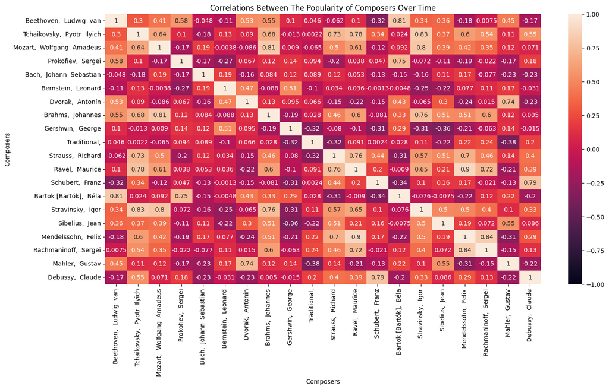

```python
plt.figure(figsize = (16, 8))

# We use the heatmap function from the seaborn library to create our graphic.
heatmap = sb.heatmap(correlation_matrix, vmin = -1, vmax = 1, annot = True)

heatmap.set_title("Correlations Between The Popularity of Composers Over Time")
heatmap.set_ylabel("Composers")
heatmap.set_xlabel("Composers")
```

We can see that several pairs of composers are strongly correlated with regards to their popularity over time. For example, Ravel and Tchaikovsky have a correlation equal to 0.78, and Mozart and Stravinsky have a correlation equal to 0.8.

The Mozart-Stravinsky relationship is particularly interesting to me, considering the rather stark contrasts between the Classical (Mozart) and Modernist (Stravinsky) styles. It suggests the NY Phil programmers intentionally opted for a contrast.

Mendelssohn and Ravel have a *super* high correlation of 0.9, suggesting that throughout the NY Phil's recent history, they have been considered as complementary by programmers (and the public).

This kind of information can give NY Phil programmers insight on historical programming trends, like what composers have paired nicely over the past decade, and so be useful for crafting programs down the road.

Returning to our second guiding question:

- Is there a relationship between composer and whether their work is featured in full or in part?

We perform a [chi-squared](https://en.wikipedia.org/wiki/Chi-squared_test) test to look for answers. This sort of statistical analysis is great for dealing with our predominantly categorical data.

- The chi-squared test measures for a significant association between categorical variables by comparing the actual frequencies with those expected.

Some important points:

- We simplify the movement category to take either:
  1. "Entire" -> to represent musical works that have been performed whole
  2. "Partial" -> to represent musical works that have been performed partially.
- We exclude intermissions. (They are not considered musical works)
- To streamline things, we narrow down to the 20 most popular composers (most frequently performed over time).

Our first step is to make a frequency/ [contingency table](https://en.wikipedia.org/wiki/Contingency_table#:~:text=In%20statistics%2C%20a%20contingency%20table,%2C%20engineering%2C%20and%20scientific%20research.).

```python
updated_clean_works_df = clean_works_df.copy()

def update_movement(x): # Function purposed to simplify the movement category

  if x == "Entire":
    return "Entire"
  else:
    return "Partial"

updated_clean_works_df["featuredPortion"] = updated_clean_works_df["movement"].apply(update_movement)

contingency_table = pd.crosstab(updated_clean_works_df["composerName"], updated_clean_works_df["featuredPortion"])
contingency_table_df = pd.DataFrame(contingency_table)

contingency_table_df["rowTotal"] = contingency_table_df.sum(axis = 1) # We add a column for row totals

contingency_table_df = contingency_table_df.drop("Intermission")

# We isolate the top 20
contingency_table_df = contingency_table_df.sort_values(by = "rowTotal", ascending = False)
contingency_table_df = contingency_table_df.head(20)

contingency_table_df
```

| featuredPortion composerName | Entire | Partial | rowTotal |
| --- | --- | --- | --- |
| Beethoven, Ludwig van | 207 | 75 | 282 |
| Tchaikovsky, Pyotr Ilyich | 152 | 129 | 281 |
| Mozart, Wolfgang Amadeus | 177 | 56 | 233 |
| Bach, Johann Sebastian | 86 | 135 | 221 |
| Bernstein, Leonard | 71 | 138 | 209 |
| Prokofiev, Sergei | 65 | 131 | 196 |
| Dvorak, Antonín | 126 | 57 | 183 |
| Brahms, Johannes | 129 | 39 | 168 |
| Traditional, | 137 | 3 | 140 |
| Gershwin, George | 99 | 20 | 119 |
| Schubert, Franz | 81 | 28 | 109 |
| Ravel, Maurice | 93 | 14 | 107 |
| Bartok [Bartók], Béla | 60 | 41 | 101 |
| Mendelssohn, Felix | 55 | 41 | 96 |
| Sibelius, Jean | 72 | 23 | 95 |
| Strauss, Richard | 52 | 36 | 88 |
| Rachmaninoff, Sergei | 75 | 9 | 84 |
| Copland, Aaron | 49 | 31 | 80 |
| Stravinsky, Igor | 67 | 11 | 78 |
| Mahler, Gustav | 53 | 22 | 75 |

Now that we have a contingency table, we visualize it with a bar graph to better internalize the relationship between frequencies.

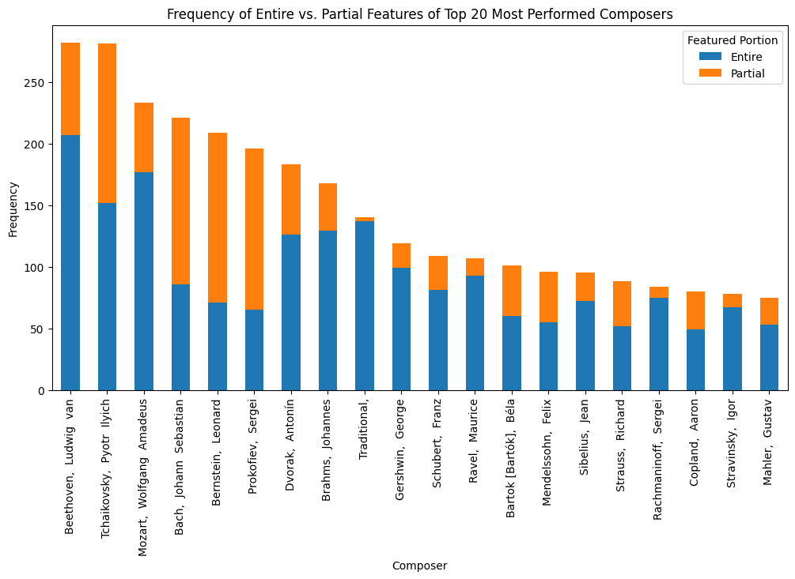

```python
contingency_table_df[["Entire", "Partial"]].plot(kind = "bar", stacked = True, figsize = (12, 6))

plt.title("Frequency of Entire vs. Partial Features of Top 20 Most Performed Composers")
plt.xlabel("Composer")
plt.ylabel("Frequency")
plt.legend(title = "Featured Portion")
```

There seems to be an association between the two categories based off a quick glance. Just look at Igor Stravinsky and Traditional.

We apply a chi-squared test and examine the resulting [p-value](https://en.wikipedia.org/wiki/P-value), assuming an [alpha](https://en.wikipedia.org/wiki/Statistical_significance) of 0.05.

But first we need our hypothesis:

- (H0): There is no association between the composer and the feature length.
- (HA): The composer and the feature length are associated with each other.

```python
# The chi2_contingency function from the scipy.stats module computes our statistic
p_value = chi2_contingency(contingency_table_df[["Entire", "Partial"]])[1]

p_value
```

```
9.951353190031644e-83
```

Our test yielded a very small p-value, which is less than our alpha value of 0.05. This suggests that the observed data is not consistent with the null hypothesis and is more in line with the alternative hypothesis, indicating that there exists a statistically significant association between composer and whether their musical works are featured in whole or in part, as suggested by the bar graph.

Returning to our third guiding question:

- Is there a significant difference in the average number of performances given by the top soloists?

We do and [ANOVA](https://en.wikipedia.org/wiki/Analysis_of_variance) test to look for anwers.

- A one-way ANOVA is used to determine if there are any statistically significant differences between the means of three or more independent groups.

Some important points:

- To streamline things, we narrow down to the top most popular composers (most frequently performed over time).

We first create a new DataFrame detailing the frequency a given soloist performs each each season.

```python
# We must merge to create one DataFrame which links soloists to seasons.
merged_clean_soloists_programs_df = pd.merge(clean_soloists_df, clean_programs_df, on = "programID", how = "inner")
merged_clean_soloists_programs_df = merged_clean_soloists_programs_df[["soloistName", "season"]]

# We group our DataFrame by (soloist, season) pairs to get the of appearances each season per soloist.
performances_by_soloist_season_df = merged_clean_soloists_programs_df.groupby(["soloistName", "season"]).size().reset_index(name = "numberOfPerformances")
performances_by_soloist_season_df = performances_by_soloist_season_df.pivot(index = "soloistName", columns = "season", values = "numberOfPerformances").fillna(0)

# We sum across rows and the isolate top 10.
performances_by_soloist_season_df["total"] = performances_by_soloist_season_df.sum(axis = 1)
performances_by_soloist_season_df = performances_by_soloist_season_df.sort_values(by = "total", ascending = False).head(10)
performances_by_soloist_season_df = performances_by_soloist_season_df.drop(columns = "total") # We don't need this column post isolation.

performances_by_soloist_season_df
```

| season soloistName | 2011-12 | 2012-13 | 2013-14 | 2014-15 | 2015-16 | 2016-17 | 2017-18 | 2018-19 | 2019-20 | 2020-21 | 2021-22 | 2022-23 | 2023-24 |
| --- | --- | --- | --- | --- | --- | --- | --- | --- | --- | --- | --- | --- | --- |
| Young, Rebecca | 8.0 | 14.0 | 11.0 | 19.0 | 26.0 | 25.0 | 9.0 | 9.0 | 3.0 | 0.0 | 5.0 | 5.0 | 1.0 |
| Huebner, Eric | 2.0 | 7.0 | 3.0 | 27.0 | 26.0 | 18.0 | 13.0 | 19.0 | 6.0 | 0.0 | 4.0 | 7.0 | 0.0 |
| Alessi, Joseph | 21.0 | 22.0 | 32.0 | 3.0 | 23.0 | 22.0 | 0.0 | 2.0 | 0.0 | 0.0 | 0.0 | 3.0 | 1.0 |
| Baer, Alan | 17.0 | 28.0 | 28.0 | 0.0 | 22.0 | 18.0 | 0.0 | 0.0 | 1.0 | 7.0 | 0.0 | 0.0 | 1.0 |
| Bensdorf, Ethan | 17.0 | 19.0 | 30.0 | 1.0 | 22.0 | 14.0 | 0.0 | 2.0 | 0.0 | 15.0 | 0.0 | 1.0 | 0.0 |
| Brey, Carter | 8.0 | 17.0 | 12.0 | 10.0 | 11.0 | 15.0 | 11.0 | 16.0 | 9.0 | 1.0 | 5.0 | 1.0 | 1.0 |
| Vickery, Nathan | 0.0 | 0.0 | 3.0 | 9.0 | 33.0 | 12.0 | 14.0 | 12.0 | 12.0 | 5.0 | 6.0 | 5.0 | 5.0 |
| Staples, Sheryl | 15.0 | 26.0 | 11.0 | 15.0 | 9.0 | 13.0 | 7.0 | 6.0 | 5.0 | 1.0 | 3.0 | 2.0 | 1.0 |
| Kudo, Sumire | 8.0 | 13.0 | 9.0 | 4.0 | 14.0 | 16.0 | 7.0 | 9.0 | 19.0 | 2.0 | 3.0 | 5.0 | 1.0 |
| Deane, Richard | 0.0 | 2.0 | 0.0 | 9.0 | 23.0 | 25.0 | 6.0 | 2.0 | 0.0 | 28.0 | 0.0 | 14.0 | 1.0 |

We plot the distribution of performances given each season by each soloist to see if we can notice potential differences in the average number of performances given by each. To do this we restructure our DataFrame for [box-plotting](https://en.wikipedia.org/wiki/Box_plot), which provides a straightforward and effective way to visualize the distribution of performances across seasons for each soloist.

```python
# Restructuring.
melted_df = performances_by_soloist_season_df.reset_index().rename_axis(None, axis = 1).melt(id_vars = "soloistName",
                                                                                             value_vars = performances_by_soloist_season_df.columns,
                                                                                             var_name = "season", value_name = "numberOfPerformances")

melted_df
```

|  | soloistName | season | numberOfPerformances |
| --- | --- | --- | --- |
| 0 | Young, Rebecca | 2011-12 | 8.0 |
| 1 | Huebner, Eric | 2011-12 | 2.0 |
| 2 | Alessi, Joseph | 2011-12 | 21.0 |
| 3 | Baer, Alan | 2011-12 | 17.0 |
| 4 | Bensdorf, Ethan | 2011-12 | 17.0 |
| ... | ... | ... | ... |
| 125 | Brey, Carter | 2023-24 | 1.0 |
| 126 | Vickery, Nathan | 2023-24 | 5.0 |
| 127 | Staples, Sheryl | 2023-24 | 1.0 |
| 128 | Kudo, Sumire | 2023-24 | 1.0 |
| 129 | Deane, Richard | 2023-24 | 1.0 |

130 rows × 3 columns

Now we plot.

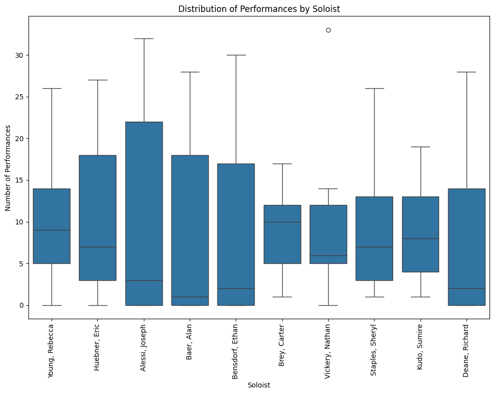

```python
plt.figure(figsize=(10, 8))
# We use the boxplot function from the seaborn library to create our graphic.
sb.boxplot(x = "soloistName", y = "numberOfPerformances", data = melted_df)
plt.xticks(rotation = 90)
plt.title("Distribution of Performances by Soloist")
plt.ylabel("Number of Performances")
plt.xlabel("Soloist")
plt.tight_layout()
plt.show()
```

With just a quick glance at the graph, it seems like the average number of performances is similar across soloists. We decide to include a point for the mean (green triangle).

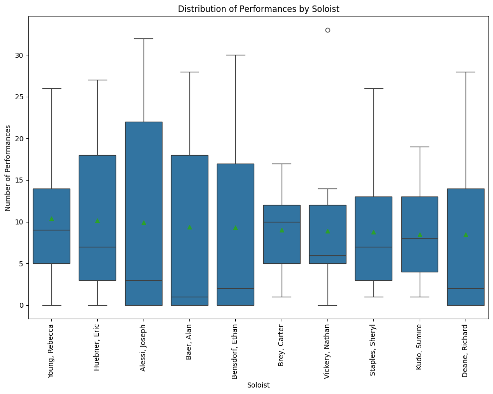

```python
plt.figure(figsize=(10, 8))
sb.boxplot(x = "soloistName", y = "numberOfPerformances", data = melted_df, showmeans = True)
plt.xticks(rotation = 90)
plt.title("Distribution of Performances by Soloist")
plt.ylabel("Number of Performances")
plt.xlabel("Soloist")
plt.tight_layout()
plt.show()
```

Again, even with the means visable, it really does seem like there isn't much difference in the average number of performances given by each soloist across seasons. For some statistical confirmation, we proceed with the ANOVA test and examine the resulting [p-value](https://en.wikipedia.org/wiki/P-value), assuming an [alpha](https://en.wikipedia.org/wiki/Statistical_significance) of 0.05.

Our hypothesis are:

H0: There is no difference among the average number of performances given by the top 10 soloists.

HA: There is a difference among the average number of performances given by the top 10 soloists.

```python
# A list for the arrays of frequencies belonging to each soloist
soloist_performances = []

for soloist in performances_by_soloist_season_df.index:
  performances = performances_by_soloist_season_df.loc[soloist].values
  soloist_performances.append(performances)

# The f_oneway function from the scipy.stats module computes our statistic
p_value = f_oneway(*soloist_performances)[1]

p_value
```

```
0.9998972774698104
```

With such a high p-value, we fail to reject H0, and conclude that there is no difference in the average number of performances across all seasons for the top 10 soloists. Our visual conclusion is statistically confirmed.

Our exploratory analysis of the dataset using various statistical methods uncovered multiple trends of interest. We found evidence that certain composers *do* tend to gain popularity alongside others over time, specifically amongst the top 20 composers. We also found evidence that there *is* a relationship between composer and whether their work is featured in full or in part, also specifically amongst the top 20 composers. Finally, we found evidence to suggest that there really *isn't* a significant difference in the average number of performances given by the top soloists, specifically amongst the top 10 soloists.

We believe our observations hold valuable for concert programmers who are tasked with structuring orchestra concert programs similar to those of the New York Phil. For instance, it could assist them in determining which composers tend to work well together and whether or not to feature certain musical works entirely or partially, as well as in deciding if a certain soloist is more appropriate to guest than another.

Our exploration sets the stage for our final steps with this project/ tutorial.

# Primary Analysis

With our guiding questions answered, we take advantage of the relationships uncovered by implementing machine learning in this next part of the data science pipeline. We focus on doing [classification](https://www.geeksforgeeks.org/getting-started-with-classification/), specifically with a [decision tree](https://www.ibm.com/topics/decision-trees). We take this approach becuase the data we have, almost exclusively categorical, is especially well suited for such techniques.

- In machine learning, classification is the [supervised](https://en.wikipedia.org/wiki/Supervised_learning) process of learning to predict a categorical label from input features.
- Decision trees are a specific kind of of classification model that predict via the splitting of data into branches at "decision nodes," and traversing the tree to a leaf based on input features.

In our exploratory analysis, we found evidence of a relationship between composer and whether their musical works tend to be performed wholly or only in part. We want to leverage this trend to build a decision tree that considers: 'composerName', 'workTitle', 'conductorName', 'programID', and 'interval' (feature variables) to predict the 'movement' (target variable) of a new work's datapoint. This will allow us to answer the remaining questions posed in our introduction:

- Can we use the trends uncovered through exploratory analysis to help select and develop a machine learning model that attempts to predict aspects of new program data? For example, given a new data point with information about: composer, conductor, intermission, work title, etc., is the work performed in whole or in part?

Our first step is to create a new DataFrame, 'encoded_clean_works_df', to represent the categorical values of 'clean_works_df' numerically. This is a process known as label encoding, and we do it to make the decision tree implementation with scikit-learn more straighforward.

However we first do some feature engineering to simplify our target column. 'movement' can presently take one of three values:

1. 'Entire' -> when the whole work is performed
2. 'Intermission' -> when the work is simply an intermission
3. *The names of select movements from a greater work, when the whole work is not performed*

It is point three that explains the great variety and sparseness of our target variable, making it extremely difficult to predict as is. But our aim is more modest. We are only interested in predicting whether a particular work is performed in whole or in part. So we call our 'update_movement' function from earlier and apply the transfromation:

1. 'Entire' -> 'Entire'
2. *Anything else* -> 'Partial

```python
encoded_clean_works_df = clean_works_df.copy()

# We perform the feature engineering described in detail above
encoded_clean_works_df['movement'] = encoded_clean_works_df['movement'].apply(update_movement)

# We use category codes for label encoding
encoded_clean_works_df['composerName'] = encoded_clean_works_df['composerName'].astype('category').cat.codes
encoded_clean_works_df['workTitle'] = encoded_clean_works_df['workTitle'].astype('category').cat.codes
encoded_clean_works_df['conductorName'] = encoded_clean_works_df['conductorName'].astype('category').cat.codes
encoded_clean_works_df['programID'] = encoded_clean_works_df['programID'].astype('category').cat.codes
encoded_clean_works_df['interval'] = encoded_clean_works_df['interval'].astype('category').cat.codes
encoded_clean_works_df['movement'] = encoded_clean_works_df['movement'].astype('category').cat.codes

encoded_clean_works_df
```

|  | composerName | workTitle | conductorName | programID | interval | movement |
| --- | --- | --- | --- | --- | --- | --- |
| 0 | 80 | 3023 | 131 | 17 | 0 | 0 |
| 1 | 449 | 1285 | 84 | 17 | 1 | 1 |
| 2 | 190 | 1759 | 30 | 92 | 0 | 1 |
| 3 | 54 | 44 | 30 | 92 | 0 | 0 |
| 4 | 237 | 713 | 30 | 92 | 0 | 0 |
| ... | ... | ... | ... | ... | ... | ... |
| 7907 | 140 | 1539 | 161 | 1490 | 0 | 0 |
| 7908 | 369 | 2282 | 161 | 1490 | 0 | 0 |
| 7909 | 1023 | 2433 | 161 | 1490 | 0 | 0 |
| 7910 | 388 | 1544 | 161 | 1490 | 0 | 0 |
| 7911 | 349 | 250 | 141 | 1415 | 0 | 0 |

7912 rows × 6 columns

With our values transformed to the liking of scikit-learn, we need to split the data in a train set and a test set. By not training the model on all of our data, reserving some for testing, we can measure its predictive performance against "new" instances to see if it generalizes well.

```python
features = encoded_clean_works_df[['composerName', 'workTitle', 'conductorName', 'programID', 'interval']]
target = encoded_clean_works_df['movement']

# We use the function train_test_split from the sklearn.model_selection module to split our data for training and testing.
# 75% of our data will be used for training, and 25% for testing by default.
features_train, features_test, target_train, target_test = train_test_split(features, target, random_state= 7)
```

Now we instantiate the model and fit our data to it/ train it.

```python
# We use the function DecisionTreeClassifier from sklearn.tree to create our decision tree model.
dt_model3 = DecisionTreeClassifier(max_depth= 3, random_state= 7)

# We call the fit function to train (using the training set).
dt_model3.fit(features_train, target_train)
```

```
DecisionTreeClassifier(max_depth=3, random_state=7)
```

With training complete, we now check out how the model performs on datapoints not yet seen, to as mentioned above, get some idea about how well it generalizes. We start by measuring the model's accuracy, which is just:

$\frac{correct\ predictions}{total\ predictions}$

We use 'features_test' to predict the target 'movement', and then compare those predictions to the actual 'movment' values in 'target_test'.

```python
# We call the predict function to generate our predicted target values.
target_predictions = dt_model3.predict(features_test)

# The accuracy_score function from sklearn.metrics computes the accuracy.
print("Accuracy: ", accuracy_score(target_test, target_predictions))
```

```
Accuracy:  0.731041456016178
```

Pretty good. Our model is correct about 73% of the time. To get an even more detailed understanding of our model's performance, we generate a classification report.

```python
# The classification_report function from sklearn.metrics generates the classification report.
print(classification_report(target_test, target_predictions, target_names= ['Entire', 'Partial']))
```

```
              precision    recall  f1-score   support

      Entire       0.70      1.00      0.82      1245
     Partial       1.00      0.27      0.43       733

    accuracy                           0.73      1978
   macro avg       0.85      0.64      0.63      1978
weighted avg       0.81      0.73      0.68      1978
```

The breaks down performance for each class ('Entire', 'Partial') into:

1. Precision -> $\frac{true\ positives}{true\ positives\ +\ false\ positives}$
2. Recall -> $\frac{true\ positives}{true\ positives\ +\ false\ negatives}$
3. F1-score -> *The harmonic mean of precision and recall*

Accross the board, our averages are ...ok...

We could probably improve the classification ability of our model by increasing tree depth (currently set to three), but this fast becomes computationally expensive. We try with a tree of depth nine.

```python
# We change max_depth to 9 from 3
dt_model9 = DecisionTreeClassifier(max_depth= 9, random_state= 7)
dt_model9.fit(features_train, target_train)
target_predictions = dt_model9.predict(features_test)
print(classification_report(target_test, target_predictions, target_names= ['Entire', 'Partial']))
```

```
              precision    recall  f1-score   support

      Entire       0.79      0.91      0.85      1245
     Partial       0.79      0.59      0.68       733

    accuracy                           0.79      1978
   macro avg       0.79      0.75      0.76      1978
weighted avg       0.79      0.79      0.78      1978
```

We see that by tripling the depth, our accuracy improves:

- 0.73 -> 0.79

# Visualization

For this next step in the pipeline, we improve our understanding of the decision tree model with a visualization. We focus on the tree with depth three (generating a graph for the tree with depth nine is expensive).

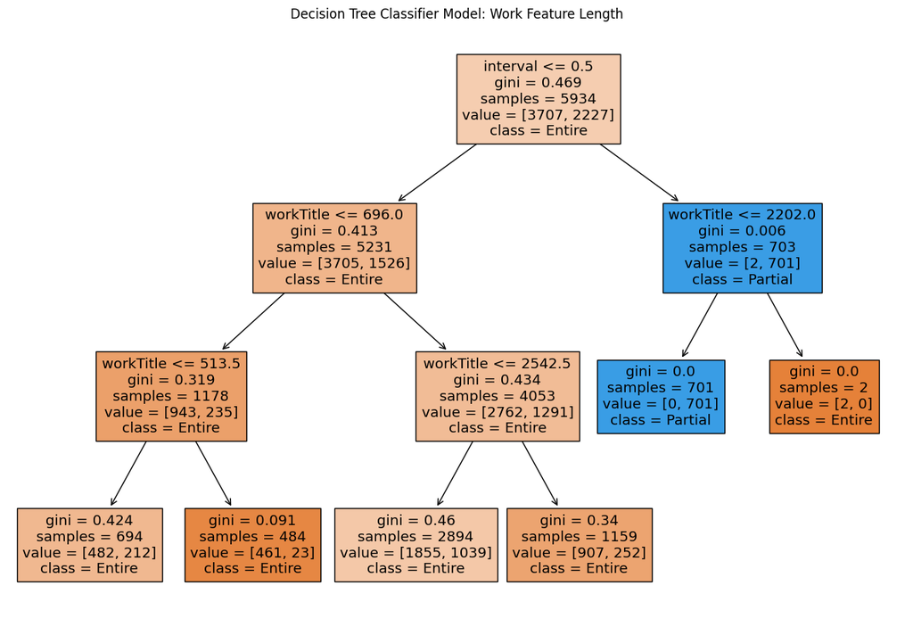

```python
# We use the plot_tree function from sklearn.tree to create our graphic.
plt.figure(figsize= (15, 10))
plot_tree(dt_model3, filled=True, feature_names=encoded_clean_works_df.columns[:-1], class_names=['Entire', 'Partial'])
plt.title('Decision Tree Classifier Model: Work Feature Length')
plt.show()
```

**Legend**

- Shade of Orange: 'Entire' class
- Shade of Blue: 'Partial' class

Nice! Notice that each node gives us a bunch of metadata. The last bit in each node, 'class', shows us how the model would have classified an input had it stopped at that depth, and the first bit, corresponding to feature names except at the leaf nodes, gives us the decision boundary in terms of our data's catergory code. Category codes can be mapped to actual names by comparing 'clean_works_df' to 'encoded_clean_works_df' by index (since we have so much data, these DataFrames contain most all of the canonical composers and works, as well as the eminent modern conductors and soloists).

We find it interesting that our model at this depth, is relying on only two featues, 'interval' and 'workTitle,' to make its predictions. It would have almost certainly been more than two had we allowed for additional growth. However this indicates that 'interval' and 'workTitle' carry a lot of weight in terms of cleanly dividing up our data for making decisions about the target variable.

# Insights and Conclusions

Our final step in the pipeline is to reflect on and articulate our newfound insights, as well as the conclusions we've come to.

Just like great works of classical music, which they systematically relate attempting to present them in their best light, concert programs must be crafted with form and flow. Taking example from one of the world's leading orchestras, the New York Philharmonic, would be an excellent way for aspiring, and even professional programmers to sharpen their skills. With the NY Phil's massive database, some statistics, and the predictive power of machine learning, this project leaves us with the insights and a blue print for programmers to do just that– create programs having learned from the best.

Through various levels of analysis, we were able to pick out many significant trends in our dataset (keeing in mind date range under consideration). For example:

- Certain composers have tended to gain popularity alongside others over time.
- Whether a work is featured in full or in part depends on the composer.

We were also able to rule trends out. For example:

- There is not a significant difference in the average number of performances given by the top soloists.

These reveals ultimately inspired the development of a predictive model that programmers can now use to determine how long they should feature a particular work. Although this only addresses one of the many questions programmers must answer when developing new material, our model is such that it can easily be jury-rigged to predict all sorts of target variables given any collection of the standard categorical features available on a concert progam. It is in this way that we have created a blueprint for programmers interested in the NY Phil's insights.

Throughout this project and our walk through the data science pipeline, our work focused on just over a decade (the most recent) of data. However there is *well over a century's* worth of data available publicly on the NY Phil's GitHub page. Has their style of programming changed from decade to decade? What longer term trends remain to be discovered? We leave these questions open to the interested.